# Graphing with ggplot2: a brief overview

Cody Flagg

Wednesday, May 27, 2015

**Goal:** A brief overview of the philosophy behind ggplot, and a demonstration of its utility and power.

# 1 ggplot2 Outline

1. Grammar of Graphics
2. Syntax
3. Basics - qplot()
4. 2010 Pathfinder Data with ggplot

# 2 Grammar of Graphics

## 2.1 Theory and Philosophy

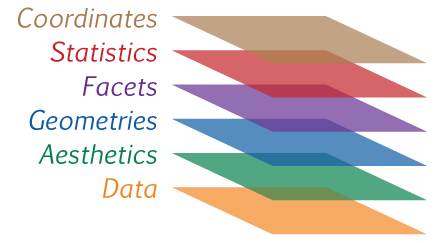

** Well, Duh! **

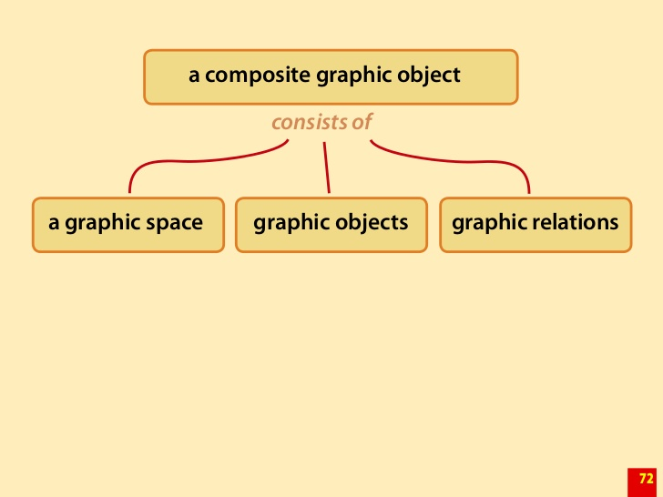

** The point here is the formalization of graphing, the clarity that formalities bring coaxs art. **

### 2.1.1 Grammar of Graphics: Finding Meaning in the Hadley-verse

- “An **abstraction** which makes thinking, reasoning, and communicating (graphics) easier.”
- R as a Language > use R to build coherent structures (sentences = single lines, paragraphs = functions, essays = workflow)
  - Not just using tools/functions as a *means to an end*, but an *end in itself*: the code, the grammar matters as much as the output.
- But also…**be lazy**. Lazy is smart. Thinking less about little, uninteresting problems allows for more abstraction and complexity in problem solving.
- Finally…web resources to jumpstart!
  - (ggplot2 cheatsheet) http://www.rstudio.com/wp-content/uploads/2015/03/ggplot2-cheatsheet.pdf
  - (R Cookbook) http://www.cookbook-r.com/Graphs/

# 3 Syntax in the Hadley-verse: ggplot2

- **Functionally** : build every graph with the same few components:
  - `data`
  - geometries (or `geom`, visual marks that represent data)
    - Map variables to `aesthetic` (or `aes`) properties in the `geom`: size, color, x, y
  - `coordinate system`
- **Additions** more options are added via additional function calls, referred to as **layers**, rather than being embedded in one long call
- **Similarities** : the “Hadley-verse” of dplyr, plyr, tidyr, reshape2 packages
  - e.g. “function(.data, .group, .arguments, …)”
  - Why is this important?
  - Connectivity (pipe your problems)
  - Reducing cluttered thought
  - Cleaner workflow = better work

# 4 Basics

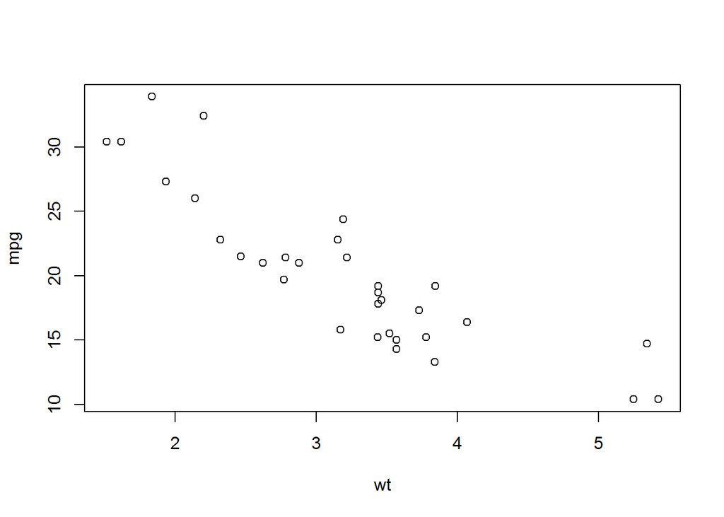

```r
# install.packages("ggplot2") # run this if you don't have ggplot2 installed
library(ggplot2) # then run this to activate the package
library(dplyr)

# base R plotting
plot(mpg ~ wt, data = mtcars)
```

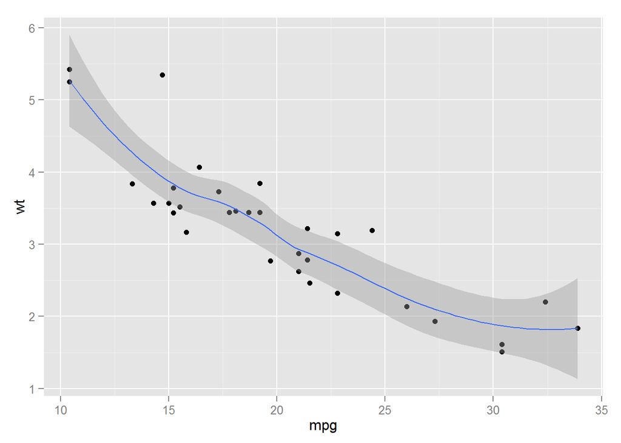

```r
# quick and simple plotting function; not for finely tuning figures
# why use qplot? It's a one line function that requires no additional layering
qplot(mpg, wt, data = mtcars, geom = c("point", "smooth"))
```

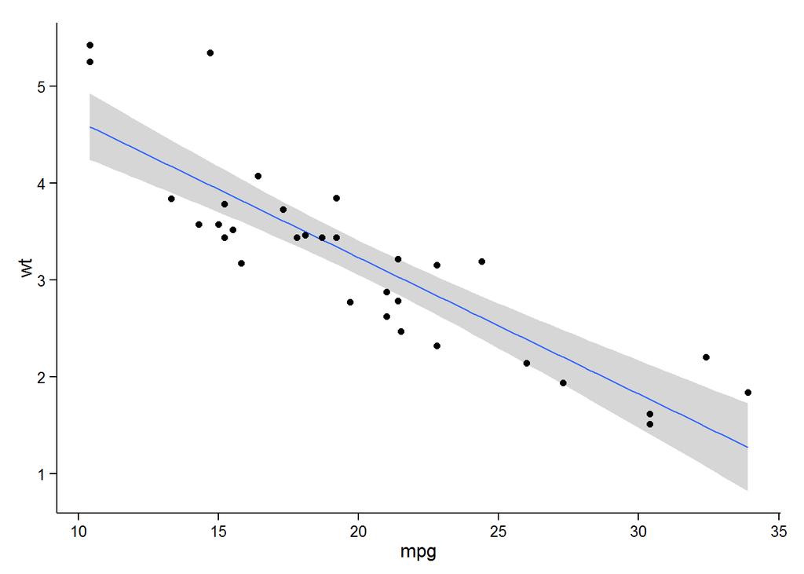

```r
# Graduating to full controls - using ggplot()
# adding a smoothing layer for a regression, point layer, and controlling the thematic background layer
ggplot(mtcars, aes(mpg,wt)) + geom_smooth(method="lm") + geom_point() + theme_classic()
```

## 4.1 Revisiting 2010 Pathfinder Data

- dplyr the target species and status

```r
vs <- read.csv("C:/Users/cflagg/Documents/GitHub/codingSupportGroup/plottingAndPublication/inputVstPathfinder2010.csv", header=TRUE)

# create target vectors to capture everything in one call
# or do it in one
vs2 <- filter(vs, species %in% c("Qula", "Pipa"), status %in% c("Alive", "Dead"))
vs2_other <- filter(vs, !(species %in% c("Qula", "Pipa"))) # species that are "not in" list "Qula", "Pipa"

# a functionable alternative?
# Set search term arguments
# target_sp = c("Pipa", "Qula")
# target_st = c("Dead","Alive")
#
# iterate over filters and pipes
# vs2 <- filter(vs, species %in% target_sp, status %in% target_st)
#'%ni%' <- Negate('%in%') # We are the knights who say "Ni!" - a "not in" logical operator (not a base R function)
# vs2_other <- filter(vs, species %ni% target_sp) # filter "It!"
```

## 4.2 Figure 1 from VST plotting

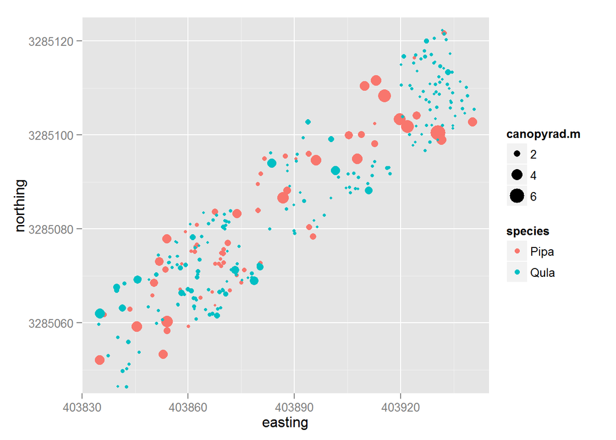

```r
E = c(403835.04, 403876.8, 403919.41, 403963.86)
N = c(3285052.24, 3285080.38, 3285104.02, 3285129.41)

# build the base graphic, assign it to a callable object
g1  <- ggplot(vs2, aes(x=easting, y = northing, color = species))  # define the primary elements of your graph
# g1 # uncomment this and run; think of this as the beginning of a "canvas" for later...

# now declare the geometry and the axis limits
g2  <- g1 + geom_point(aes(size = canopyrad.m)) + coord_cartesian(xlim=c(403830,403945), ylim=c(3285045,3285125)) # add new properties to the object
g2 # call again
```

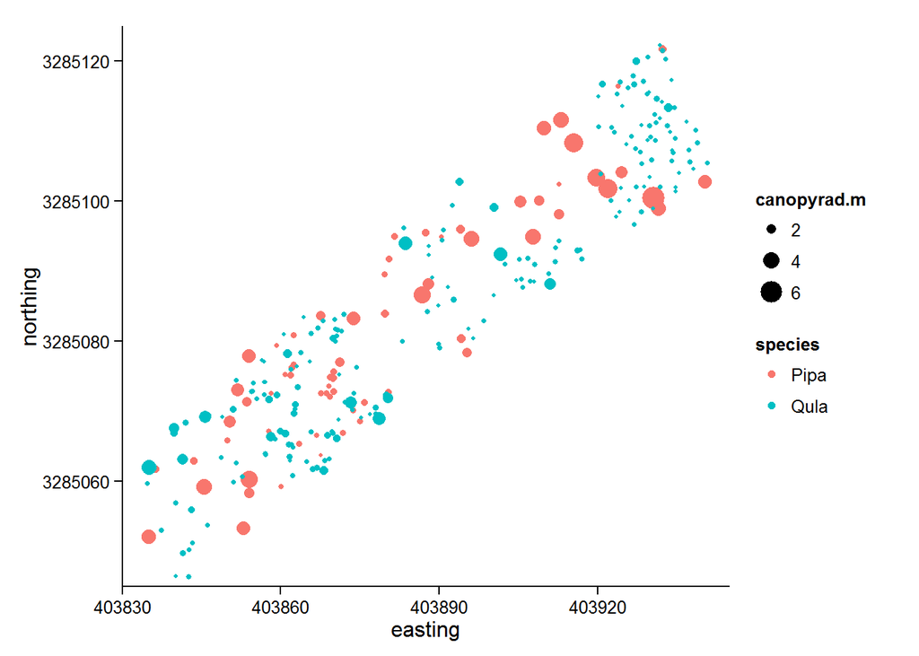

```r
# Now tweak the graphical properties
g2<- g2 + theme_classic() # kill the gray background and grid, one liner
g2
```

### 4.2.1 Add the transect from GPS data

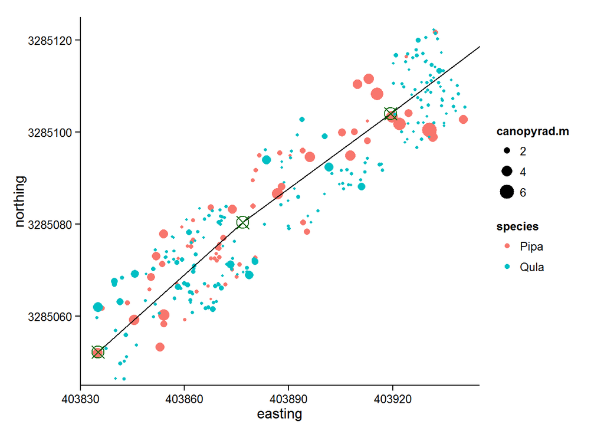

```r
# how about a "one-liner":
trans <- data.frame(easting = E,northing = N) # turn the transect line into a data frame

g2 + geom_line(aes(easting,northing),data=trans, colour = "black") +
  geom_point(aes(easting,northing), data=trans, color = "darkgreen", size = 5, shape = 13)# now add it
```

## 4.3 Why Build A Canvas?

- Back to Grammar: Abstraction >> simple Refactoring
  - **Abstraction**: a way of managing complexity. Identify a reoccurring activity, turn it into a function, method, class, or *language*, and give it a name.
  - *Be Lazy*: Let machines do boring stuff (computation); let people do cool stuff (thinking, analysis, design).
  - **Refactoring**: Reduce repetitive code activities by creating a function.
- Applied to ggplot:
  - Use the same base plot (our canvas), modify without repeating the same code.

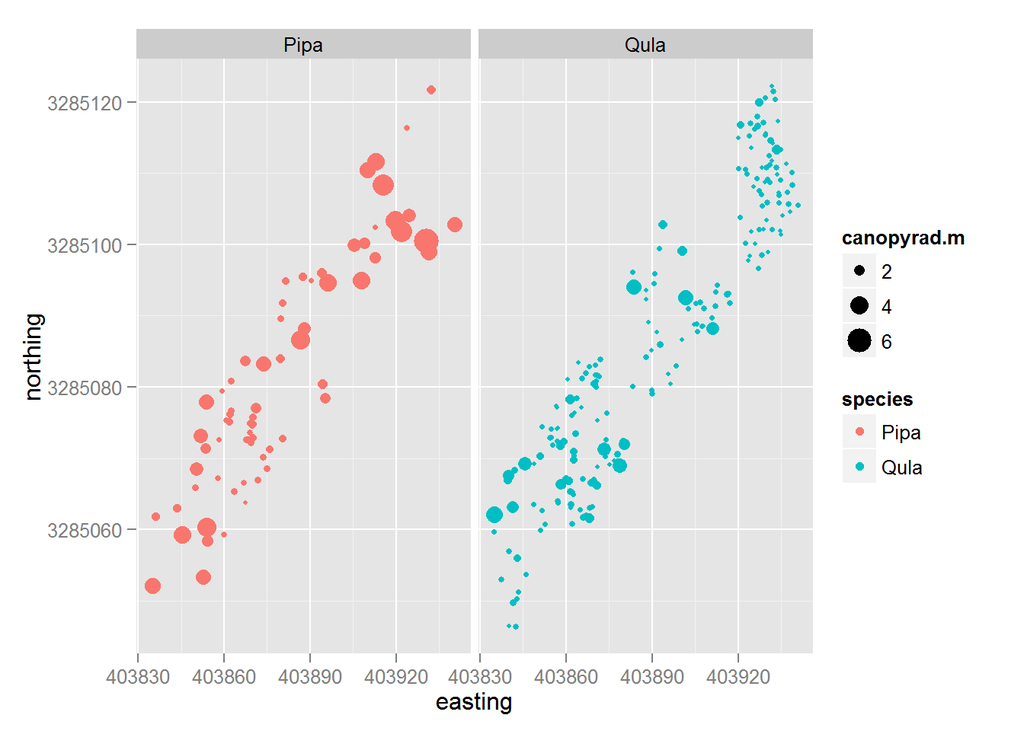

```r
g2.facet <- g1 + geom_point(aes(size = canopyrad.m)) + facet_wrap(~species)
g2.facet
```

### 4.3.1 Visualize Different Patterns - 3D plots

- 3D not an option in ggplot, why?
  - Hadley’s Philosophy: nothing quotable…but its absence speaks volumes.
  - But also, from his thesis: “While it is possible to investigate high-d objects with only static graphics, it is much easier to do so interactively.”
- Alternatives in ggplot: facet_wrap
- Where are the dead trees, and what species are they?

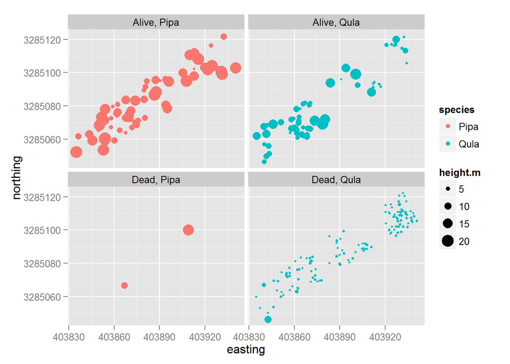

```r
g3.facet <- g1 + geom_point(aes(size = height.m)) + facet_wrap(~status+species)
g3.facet
```

**Contrast with 3D plot**

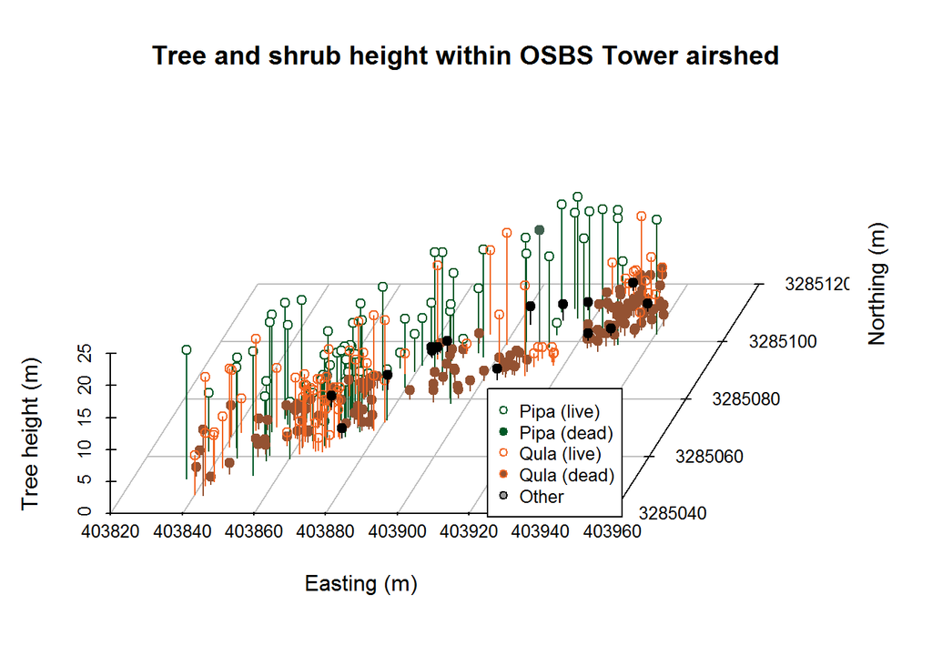

```r
library(scatterplot3d)

pipa.l = vs[which(vs$species=='Pipa' & !vs$status=='Dead'),]
pipa.d = vs[which(vs$species=='Pipa' & vs$status=='Dead'),]
qula.l = vs[which(vs$species=='Qula' & !vs$status=='Dead'),]
qula.d = vs[which(vs$species=='Qula' & vs$status=='Dead'),]
other = vs[!vs$species %in% c("Pipa","Qula"),]

s3d = scatterplot3d(pipa.l$easting, pipa.l$northing, pipa.l$height.m, type="h", main="Tree and shrub height within OSBS Tower airshed", xlab="Easting (m)", ylab="Northing (m)", zlab="Tree height (m)", pch=21, color="#005826", box=F, angle=70, scale.y=2.3, xlim=c(403830,403950), ylim=c(3285040,3285120))

s3d$points3d(pipa.d$easting, pipa.d$northing, pipa.d$height.m, type="h", pch=19, col="#41614F")
s3d$points3d(qula.d$easting, qula.d$northing, qula.d$height.m, type="h", pch=19, col="#945232")
s3d$points3d(qula.l$easting, qula.l$northing, qula.l$height.m, type="h", pch=21, col="#f26522")
s3d$points3d(other$easting, other$northing, other$height.m, type="h", pch=19)

legend(s3d$xyz.convert(403920,3285050,15), pch=21,
       col=c("#005826", "#005826", "#f26522", "#f26522", "#000000"),
       pt.bg=c("#FFFFFF", "#005826", "#FFFFFF", "#945232", "gray60"),
       legend=c("Pipa (live)", "Pipa (dead)", "Qula (live)", "Qula (dead)", "Other"),
       cex=0.8)
```

### 4.3.2 Piecing Together Hadley-verse Packages

- dplyr -> ggplot (subset and plot)
- In a galaxy far far away… tidyr -> reshape2 -> dplyr -> ggplot

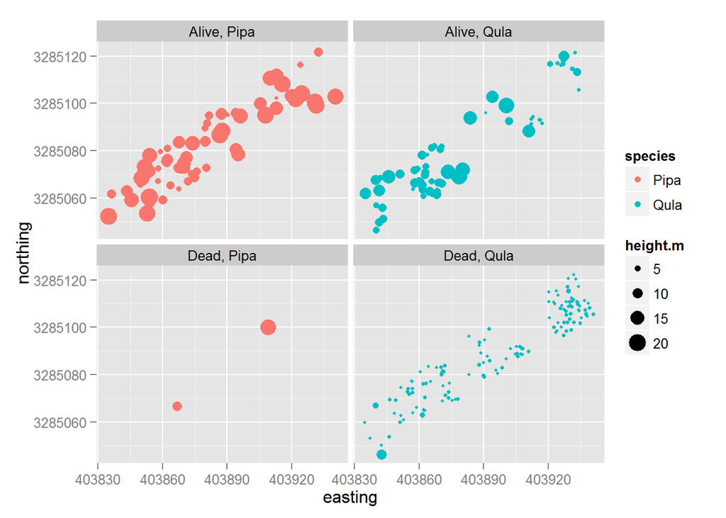

```r
# in one go - one dataset call
vs  %>%
  filter(species %in% c("Qula", "Pipa"), status %in% c("Alive", "Dead"))  %>%
  ggplot(aes(x=easting, y = northing, color = species)) +
  facet_wrap(~status+species) +
  geom_point(aes(size = height.m))
```